# Numerai Financial Analysis

Last updated: 2024-02-23

## Preliminary Work: Install/Load Packages

To try and ensure that this R Notebook will run successfully, we’ll use the [renv package](https://cran.r-project.org/web/packages/renv/index.html) to create a project-specific library of packages. This will allow us to install the packages that we need for this project without affecting any other projects that we may be working on. Additionally, the project library will track the specific versions of the dependency packages so that any updates to those packages will not break this project.

The code chunk below will first install the renv package if it is not already installed. Then we will load the package. Next, we’ll use the `restore()` function to install any packages listed in the renv.lock file. Once these packages are installed, we can load them into the R session using the `library()` commands. Below the code chunk, we’ll list out the packages that will be used in the project demo. And if you run into any trouble using renv, then you can use the second code chunk below and that should be an even more reliable approach to install the required packages.

```r
# Install renv package if not already installed
if(!"renv" %in% installed.packages()[,"Package"]) install.packages("renv")
# Load renv package
library(renv)
# Use restore() to install any packages listed in the renv.lock file
renv::restore(clean=TRUE, lockfile="../renv.lock")
# Load in the packages
library(fredr)
library(quantmod)
library(readr)
library(xts)
library(lubridate)
library(ggplot2)
library(dplyr)
```

- The [fredr package](https://cran.r-project.org/package=fredr) is an R package that wraps the FRED API for easy importing of FRED data into R.
- The [quantmod package](https://cran.r-project.org/package=quantmod) contains tools for importing and analyzing financial data.
- The [readr package](https://cran.r-project.org/package=readr) is a package for reading in data files. We’ll use it to read in the csv file from the Numerai Fund website.
- The [xts package](https://cran.r-project.org/package=xts) is short for ‘eXtensible Time Series’, which contains tools for working with time series data.
- The [lubridate package](https://cran.r-project.org/package=lubridate) simplifies calculation involving dates.
- The [ggplot2 package](https://cran.r-project.org/package=ggplot2) for graphics and visuals.
- The [dplyr package](https://cran.r-project.org/package=dplyr) contains tools for data manipulation.

Since the rmarkdown functionality is built into RStudio, this one is automatically loaded when we open the RStudio. So no need to use the `library()` function for this one. Another observation to make about the code chunk above is that it is labeled as ‘setup’, which is a special name, which the R Notebook will recognize and automatically run prior to running any other code chunk. This is useful for loading in packages and setting up other global options that will be used throughout the notebook.

Then if you wish to try and update the versions of the various R packages in the lock file, you can use the `renv::update()` function to update the packages in the project library. However, it is possible that these updates could break the code in this notebook. If so, you may need to adapt the code to work with the updated packages.

My recommendation is to first run through the code using the versions of the packages in the lock file. Then if you want to try and update the packages, you can do so and then run through the code again to see if it still works. If not, you can always revert back to the lock file versions using the `renv::restore()` function.

If you update the packages and get everything working successfully, then you can update the lock file using the `renv::snapshot()` function. This will update the lock file with the versions of the packages that are currently installed in the project library. Then you can commit the updated lock file to the repository so that others can use the updated versions of the packages.

### Alternative Package Installation Code

If you run into any trouble using renv in the code chunk above, then you can use the code chunk below to install the required packages for this analysis. This method will first check if you have already installed the packages. If any are missing, it will then install them. Then it will load the packages into the R session. A potential flaw in this approach compared to using renv is that it will simply install the latest versions of the packages, which could potentially break some of the code in this notebook if any of the updates aren’t backwards compatible.

As long as you have downloaded the entire project repository, the renv chunk above will likely be managing the packages. Thus, the `eval=FALSE` option is used to prevent this chunk from running unless manually executed. So if you only downloaded this one Rmd file, this code chunk should take care of installing the packages for you.

```r
# Create list of packages needed for this exercise
list.of.packages = c("fredr",
                     "quantmod",
                     "readr",
                     "xts",
                     "lubridate",
                     "ggplot2",
                     "dplyr",
                     "rmarkdown")
# Check if any have not yet been installed
new.packages = list.of.packages[!(list.of.packages %in% installed.packages()[,"Package"])]
# If any need to be installed, install them
if(length(new.packages)) install.packages(new.packages)
# Load in the packages
library(fredr)
library(quantmod)
library(readr)
library(xts)
library(lubridate)
library(ggplot2)
library(dplyr)
```

## Import and Clean Data

We will be collecting data from three different sources here. First, we’ll import the monthly returns for the Numerai One and Numerai Supreme hedge funds from the [Numerai Fund website](https://numerai.fund/). Second, we’ll import the monthly returns for the S&P 500 index from the [FRED website](https://fred.stlouisfed.org/). Lastly, we’ll import the monthly returns for the Numeraire (NMR) token and Ether (ETH) from [Yahoo Finance](https://finance.yahoo.com/) via the quantmod package. The code below will import the data from each of these sources and clean it up for analysis.

### Numerai Hedge Fund Performance Data

Due to their classification as hedge funds, there is far less publicly-available information compared to mutual funds or ETFs. However, since Numerai self-publishes data for monthly fund returns on their webpage, we can make use of this to examine the performance and test their claim of investing with a market-neutral strategy. To find the url for the code chunk below, go to the main [fund website](https://numerai.fund/) and right-click on “Download Performance” and select “Copy link address.” If you left-click on the link, most browsers will simply attempt to download the current csv file. However, we can incorporate the static url into our script here and access the csv with `read_csv()`. This should retrieve all the most recent data each time this code is run.

```r
url = "https://api-financial.numer.ai/get_lp_performance_csv"
fundrets = read_csv(url, show_col_types=FALSE)
```

Now, let’s take the monthly returns from the data and convert them to an xts object of annualized percentages. Take note of the date conversion in the `order.by` parameter. Since these dates are the last day of each month, we add one date and subtract one month to convert the date to the first day of each respective month. This is in anticipation of merging with the FRED data that will be imported below, which uses dates at the beginning of each month.

```r
nmr = data.frame(nmr_one=fundrets$numerai_one_monthly_return_net_of_fees*12*100,
                     nmr_sup=fundrets$supreme_monthly_return_net_of_fees*12*100)
nmr = xts(nmr,
          order.by=fundrets$month_end_date + days(1) - months(1))
```

For the Numerai Supreme Fund, the data shows a 0% return prior to the launch of the fund in August 2022. To avoid the models from actually interpreting a 0% return, let’s replace those 0’s with missing values `NA`. The xts package makes this easier by allowing us to index by time. The `"/2022-07-01"` in the square brackets specifies the rows corresponding to dates up to and including July 2022.

```r
nmr$nmr_sup["/2022-07-01"] = NA
```

Then to simplify the download of the FRED data, let’s save the date of the earliest observation to `startdate`. This will help us only download the data that we will actually need for the analysis. Then, `startdate_1` will go back one additional month for the FRED download since we will lose an observation due to differencing. Similarly, `startdate_2` will go back two months from `startdate`, which is what downloads the correct amount of data for the crypto assets.

```r
startdate = min(fundrets$month_end_date)
startdate_1 = startdate %m-% months(1)
startdate_2 = startdate %m-% months(2)
```

### FRED Data Import

To access the FRED API, you must first create an account and [request an API key](https://fred.stlouisfed.org/docs/api/api_key.html). If you wish to run the code and replicate the results, you’ll need to make an account, generate your own API key, and run this command un-commented with your key in place of the placeholder text.

```r
#fredr_set_key("<YOUR-FRED-API-KEY>")
```

Using the `fredr()` function, we will import the 10-year Treasury note yields. This is a typical proxy for the risk-free return when applying CAPM and calculating stock betas. The Sys.Date function is simply using the computer’s current time to get the most up-to-date data.

```r
RFraw = fredr(
  series_id = "DGS10",
  observation_start = startdate,
  observation_end = as.Date(Sys.Date()),
  frequency = "m"
)
INFraw = fredr(
  series_id = "CPIAUCSL",
  observation_start = startdate_1,
  observation_end = as.Date(Sys.Date()),
  frequency = "m"
)
SPraw = fredr(
  series_id = "SP500",
  observation_start = startdate_1,
  observation_end = as.Date(Sys.Date()),
  frequency = "m"
)
```

Next, calculate the inflation rates from the CPI and merge those annualized growth rates to the merged data frame.

```r
INF = xts(INFraw,order.by=INFraw$date)
colnames(INF)[colnames(INF)=="value"] = "CPI"
INF = subset(INF,select=-c(date,series_id,realtime_start,realtime_end))
INF$INFmonthly = log(as.numeric(INF$CPI)) - log(as.numeric(lag(INF$CPI)))
INF$inf = INF$INFmonthly*12*100
```

Now convert the S&P 500 index levels into annualized market returns and merge to `ALL`.

```r
SP500 = xts(SPraw,order.by=SPraw$date)
colnames(SP500)[colnames(SP500)=="value"] = "SP500"
SP500 = subset(SP500,select=-c(date,series_id,realtime_start,realtime_end))
SP500$SPmonthly = log(as.numeric(SP500$SP500)) - log(as.numeric(lag(SP500$SP500)))
SP500$sp500 = SP500$SPmonthly*12*100
```

### NMR and ETH Price Data

In addition to the Numerai Fund data, let’s also import the price data for the Numeraire (NMR) token and Ether (ETH), which is the native token of the Ethereum blockchain that NMR transacts on.

```r
tickers = c("ETH-USD",
            "NMR-USD")
getSymbols(tickers,
           src="yahoo",
           from=startdate_2,
           to=Sys.Date(),
           periodicity="monthly")
```

First, we’ll give the crypto data names that do not have a special character (`-`), then we’ll compute the continuously compounded annual returns for the monthly data series.

```r
ETH = `ETH-USD`
NMR = `NMR-USD`
# Compute returns
ETH$Return = c(NA, diff(log(as.numeric(ETH$`ETH-USD.Adjusted`))))
NMR$Return = c(NA, diff(log(as.numeric(NMR$`NMR-USD.Adjusted`))))
# Annualize returns
ETH$ETH = ETH$Return*12*100
NMR$NMR = NMR$Return*12*100
```

### Merging and Cleaning

Now, let’s merge all these variables to a single data frame named `ALL`.

```r
ALL = xts(RFraw,order.by=RFraw$date)
colnames(ALL)[colnames(ALL)=="value"] = "rf"
ALL = subset(ALL,select=-c(date,series_id,realtime_start,realtime_end))
ALL = merge(ALL,
            INF$inf,
            SP500$sp500,
            nmr$nmr_one,
            nmr$nmr_sup,
            NMR$NMR,
            ETH$ETH)
```

Then the last cleaning step is to remove any missing values. The `complete.cases()` function returns the indices (rows) of observations with no missing values.

```r
ntrim = sum(!complete.cases(tail(ALL)))
FINAL = ALL[2:(nrow(ALL)-ntrim),]
```

## Data Summaries and Plots

When summarizing and visualizing the asset returns, we’ll begin with the nominal returns. Then we’ll examine the real (inflation-adjusted) return series. Lastly, we’ll convert each of those return series into risk premiums, resulting in a nominal risk premium and a real risk premium. Then we can compare those two sets of results to see the impact of inflation on the observed relationships.

### Nominal Returns

Let’s first take a look at what each time series looks like:

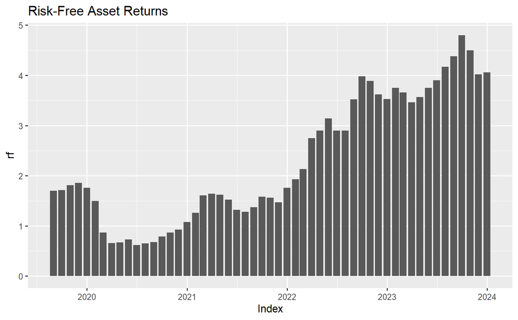

```r
ggplot(FINAL,aes(x=Index,y=rf))+
  geom_col()+
  ggtitle("Risk-Free Asset Returns")
```

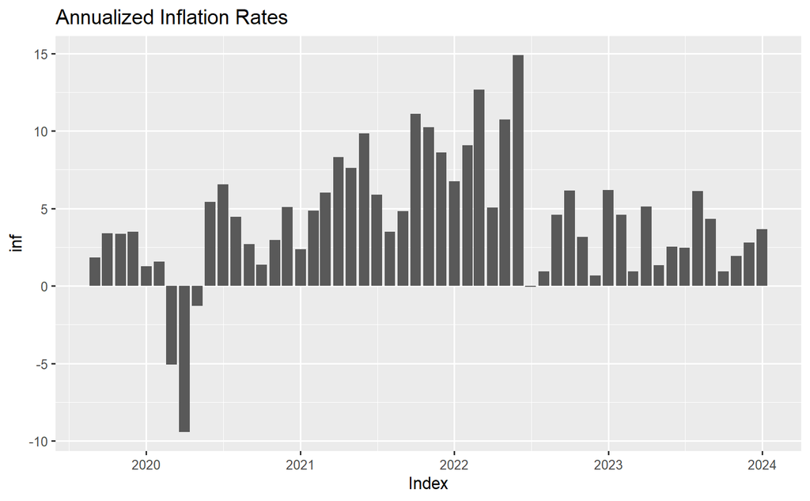

```r
ggplot(FINAL,aes(x=Index,y=inf))+
  geom_col()+
  ggtitle("Annualized Inflation Rates")
```

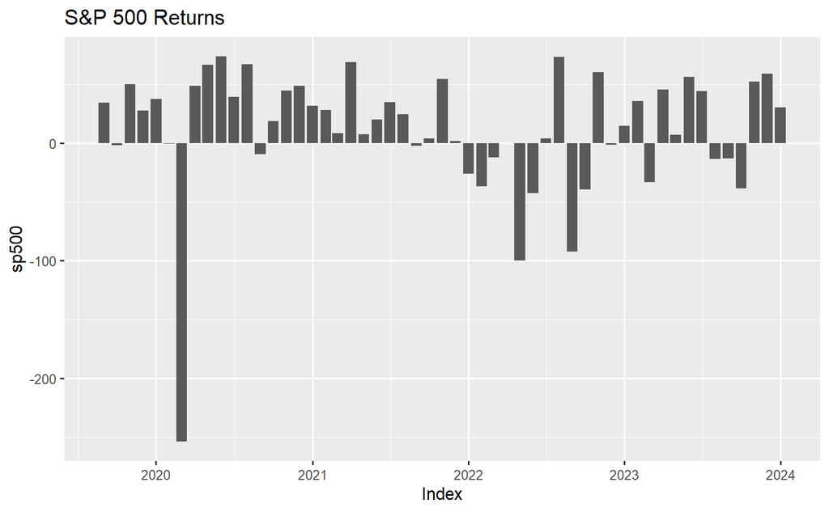

```r
ggplot(FINAL,aes(x=Index,y=sp500))+
  geom_col()+
  ggtitle("S&P 500 Returns")
```

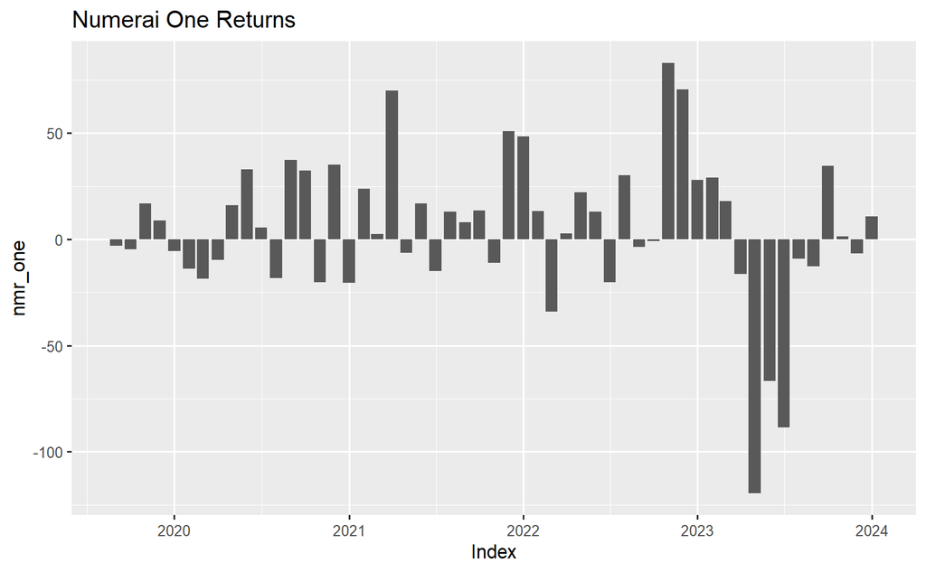

```r
ggplot(FINAL,aes(x=Index,y=nmr_one))+
  geom_col()+
  ggtitle("Numerai One Returns")
```

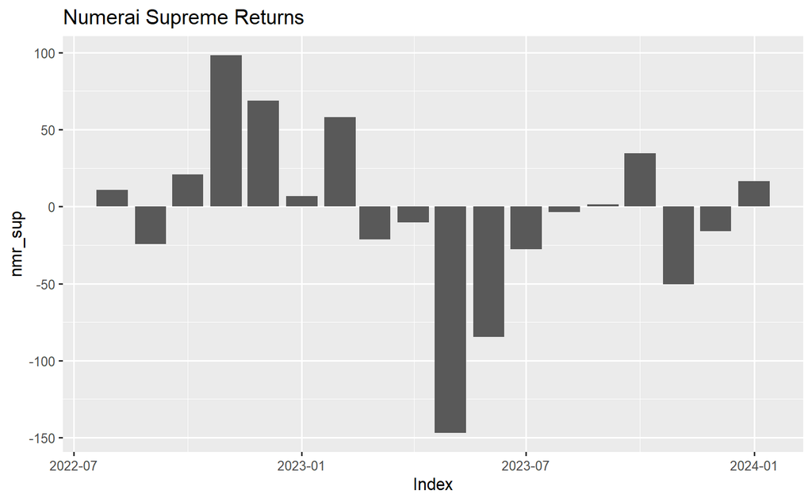

```r
ggplot(FINAL,aes(x=Index,y=nmr_sup))+
  geom_col()+
  ggtitle("Numerai Supreme Returns")
```

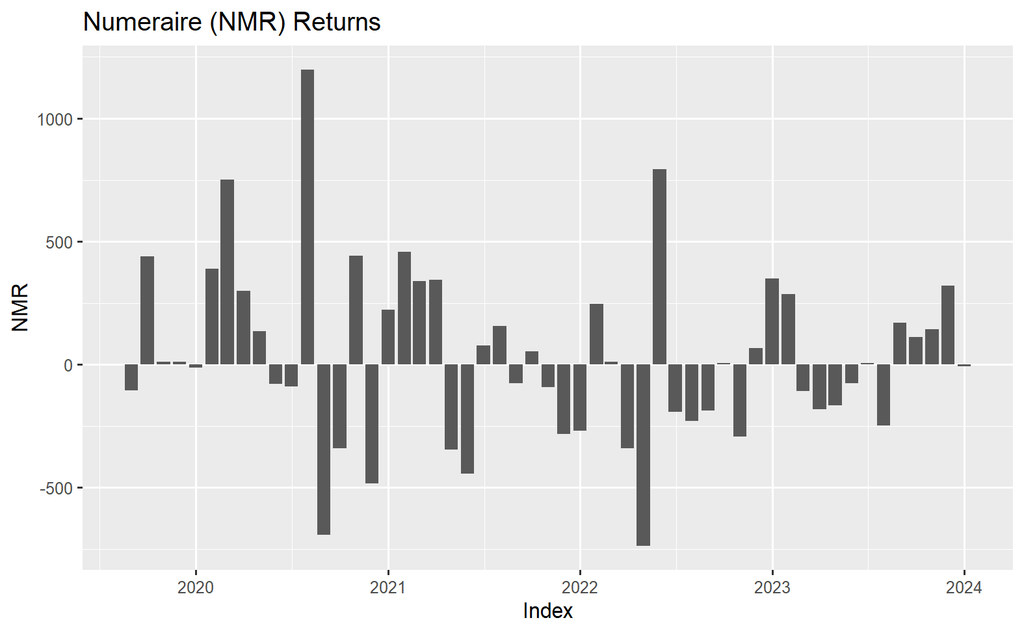

```r
ggplot(FINAL,aes(x=Index,y=NMR))+
  geom_col()+
  ggtitle("Numeraire (NMR) Returns")
```

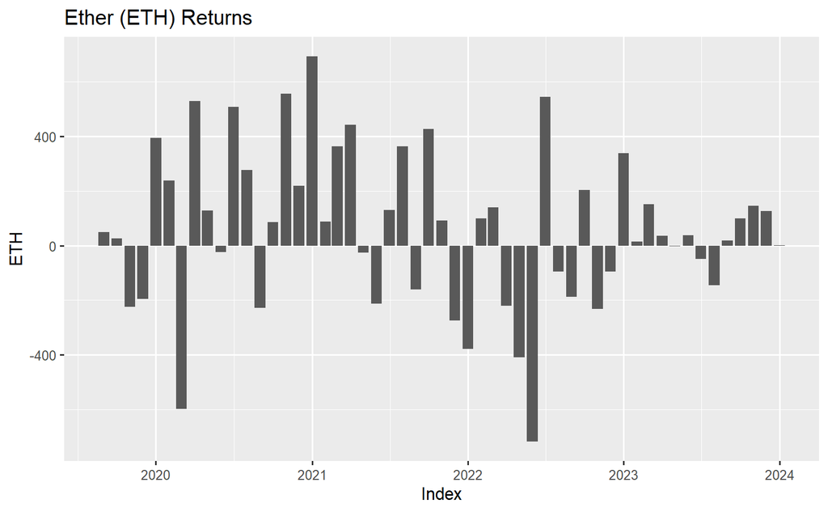

```r
ggplot(FINAL,aes(x=Index,y=ETH))+
  geom_col()+
  ggtitle("Ether (ETH) Returns")
```

Next, let’s calculate the average annual return (mean) and volatility (standard deviation).

```r
Er_nom = colMeans(FINAL,na.rm=TRUE)
Er_nom |> round(2)
```

```
     rf     inf   sp500 nmr_one nmr_sup     NMR     ETH
   2.30    4.31   11.45    5.00   -3.84   32.98   58.48
```

```r
sigma_nom = apply(FINAL,2,sd,na.rm=TRUE)
sigma_nom |> round(2)
```

```
     rf     inf   sp500 nmr_one nmr_sup     NMR     ETH
   1.28    4.11   53.75   34.84   55.90  354.39  290.79
```

Then let’s compare the correlations across all these asset returns:

```r
Rho = cor(FINAL, use="pairwise.complete.obs")
Rho |> round(2)
```

```
           rf   inf sp500 nmr_one nmr_sup   NMR   ETH
rf       1.00  0.03 -0.09   -0.12    0.09 -0.10 -0.21
inf      0.03  1.00  0.00    0.15    0.17 -0.13 -0.21
sp500   -0.09  0.00  1.00    0.04    0.00 -0.04  0.47
nmr_one -0.12  0.15  0.04    1.00    0.88 -0.15 -0.16
nmr_sup  0.09  0.17  0.00    0.88    1.00  0.13 -0.20
NMR     -0.10 -0.13 -0.04   -0.15    0.13  1.00  0.22
ETH     -0.21 -0.21  0.47   -0.16   -0.20  0.22  1.00
```

### Real Returns

To calculate real returns from the nominal returns, we must subtract the inflation rate, and then divide the difference by the quantity of (1+inflation). Note that the inflation percentage must be divided by 100 to convert back to a decimal.

```r
REAL = xts(order.by=index(FINAL))
REAL$rf = (FINAL$rf-FINAL$inf)/(1+(FINAL$inf/100))
REAL$sp500 = (FINAL$sp500-FINAL$inf)/(1+(FINAL$inf/100))
REAL$nmr_one = (FINAL$nmr_one-FINAL$inf)/(1+(FINAL$inf/100))
REAL$nmr_sup = (FINAL$nmr_sup-FINAL$inf)/(1+(FINAL$inf/100))
REAL$NMR = (FINAL$NMR-FINAL$inf)/(1+(FINAL$inf/100))
REAL$ETH = (FINAL$ETH-FINAL$inf)/(1+(FINAL$inf/100))
```

Now let’s compare the means, standard deviations, and correlations for these inflation-adjusted return series:

```r
Er_real = colMeans(REAL,na.rm=TRUE)
Er_real |> round(2)
```

```
     rf   sp500 nmr_one nmr_sup     NMR     ETH
  -1.77    6.98    0.61   -6.99   29.62   54.41
```

```r
sigma_real = apply(REAL,2,sd,na.rm=TRUE)
sigma_real |> round(2)
```

```
     rf   sp500 nmr_one nmr_sup     NMR     ETH
   4.06   53.79   33.37   54.48  339.20  280.87
```

```r
Rho_real = cor(REAL, use="pairwise.complete.obs")
Rho_real |> round(2)
```

```
           rf sp500 nmr_one nmr_sup   NMR   ETH
rf       1.00  0.02   -0.08   -0.11  0.14  0.15
sp500    0.02  1.00    0.04   -0.01 -0.06  0.49
nmr_one -0.08  0.04    1.00    0.88 -0.14 -0.14
nmr_sup -0.11 -0.01    0.88    1.00  0.12 -0.22
NMR      0.14 -0.06   -0.14    0.12  1.00  0.22
ETH      0.15  0.49   -0.14   -0.22  0.22  1.00
```

### Risk Premiums

Then to normalize risk by the risk-free rate, we can difference each return series by the risk-free rate to compute risk premiums (or excess returns). This can be done with the nominal returns or the real returns. So let’s do each and compare how inflation-adjusting the returns impacts the results.

```r
XSnom = xts(order.by=index(FINAL))
XSnom$sp500 = FINAL$sp500-FINAL$rf
XSnom$nmr_one = FINAL$nmr_one-FINAL$rf
XSnom$nmr_sup = FINAL$nmr_sup-FINAL$rf
XSnom$NMR = FINAL$NMR-FINAL$rf
XSnom$ETH = FINAL$ETH-FINAL$rf
```

```r
XSreal = xts(order.by=index(REAL))
XSreal$sp500 = REAL$sp500-REAL$rf
XSreal$nmr_one = REAL$nmr_one-REAL$rf
XSreal$nmr_sup = REAL$nmr_sup-REAL$rf
XSreal$NMR = REAL$NMR-REAL$rf
XSreal$ETH = REAL$ETH-REAL$rf
```

For each set of risk premiums, let’s compute the average annual returns and volatilities, as well as the correlation matrices to see how much the fund returns co-move with the market returns of the S&P 500.

```r
xsEr_nom = colMeans(XSnom, na.rm=TRUE)
xsEr_nom |> round(2)
```

```
  sp500 nmr_one nmr_sup     NMR     ETH
   9.15    2.69   -7.70   30.68   56.18
```

```r
xssigma_nom = apply(XSnom, 2, sd, na.rm=TRUE)
xssigma_nom |> round(2)
```

```
  sp500 nmr_one nmr_sup     NMR     ETH
  53.88   35.01   55.86  354.52  291.06
```

```r
xsRho_nom = cor(XSnom, use="pairwise.complete.obs")
xsRho_nom |> round(2)
```

```
        sp500 nmr_one nmr_sup   NMR   ETH
sp500    1.00    0.05    0.00 -0.04  0.47
nmr_one  0.05    1.00    0.88 -0.15 -0.15
nmr_sup  0.00    0.88    1.00  0.12 -0.20
NMR     -0.04   -0.15    0.12  1.00  0.22
ETH      0.47   -0.15   -0.20  0.22  1.00
```

```r
xsEr_real = colMeans(XSreal, na.rm=TRUE)
xsEr_real |> round(2)
```

```
  sp500 nmr_one nmr_sup     NMR     ETH
   8.75    2.38   -7.62   31.39   56.18
```

```r
xssigma_real = apply(XSreal, 2, sd, na.rm=TRUE)
xssigma_real |> round(2)
```

```
  sp500 nmr_one nmr_sup     NMR     ETH
  53.87   33.92   54.72  338.67  280.28
```

```r
xsRho_real = cor(XSreal, use="pairwise.complete.obs")
xsRho_real |> round(2)
```

```
        sp500 nmr_one nmr_sup   NMR   ETH
sp500    1.00    0.05   -0.01 -0.07  0.48
nmr_one  0.05    1.00    0.88 -0.15 -0.15
nmr_sup -0.01    0.88    1.00  0.12 -0.21
NMR     -0.07   -0.15    0.12  1.00  0.22
ETH      0.48   -0.15   -0.21  0.22  1.00
```

## Sharpe Ratios and CAPM Betas

From the risk premiums, we can easily compute the Sharpe ratio of the S&P 500 and the Numerai One hedge fund to compare risk-adjusted returns.

```r
sharpes_nom = xsEr_nom/xssigma_nom
sharpes_nom |> round(2)
```

```
  sp500 nmr_one nmr_sup     NMR     ETH
   0.17    0.08   -0.14    0.09    0.19
```

```r
sharpes_real = xsEr_real/xssigma_real
sharpes_real |> round(2)
```

```
  sp500 nmr_one nmr_sup     NMR     ETH
   0.16    0.07   -0.14    0.09    0.20
```

### Numerai One

To estimate the fund’s alpha and beta from CAPM, we’ll run a linear regression model of each set of fund risk premiums on the market risk premium. The p-value (`Pr(>|t|)`) for the beta (`sp500`) estimate is for a statistical test where the null hypothesis is that the fund has a beta of zero. This property of a zero beta corresponds with a strategy of market neutrality. In other words, if the market goes up or down by any amount, the expected return of the fund should be unchanged. The alpha (intercept) estimate then indicates the beta-neutral performance of the fund. As of January 2024, the beta estimate for Numerai One is 0.03 in both nominal and real units. With t-stats under 0.5 for those estimates, this lack of statistical significance provides good evidence in support of their claim to invest with a market-neutral strategy. The alpha estimates are a little over 2% in both nominal and real units suggesting a modest return. In both cases, the $R^2$ of is fairly small (<1%), which also follows well given the claim of market-neutrality.

```r
NMR_one_fit_nom = lm(nmr_one~sp500,data=XSnom)
summary(NMR_one_fit_nom)
```

```
Call:
lm(formula = nmr_one ~ sp500, data = XSnom)

Residuals:
     Min       1Q   Median       3Q      Max
-125.738  -15.059    1.328   19.836   75.048

Coefficients:
            Estimate Std. Error t value Pr(>|t|)
(Intercept)  2.41985    4.92155   0.492    0.625
sp500        0.02991    0.09089   0.329    0.743

Residual standard error: 35.31 on 51 degrees of freedom
Multiple R-squared:  0.002119,  Adjusted R-squared:  -0.01745
F-statistic: 0.1083 on 1 and 51 DF,  p-value: 0.7435
```

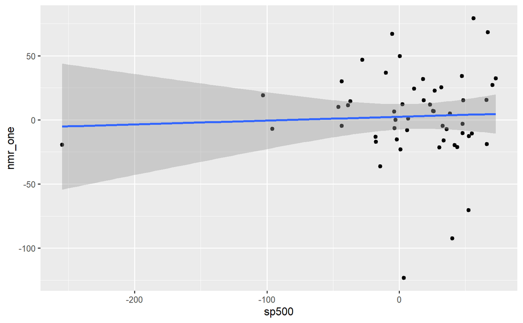

```r
ggplot(XSnom,aes(x=sp500,y=nmr_one))+
  geom_point()+
  geom_smooth(method="lm")
```

```r
NMR_one_fit_real = lm(nmr_one~sp500,data=XSreal)
summary(NMR_one_fit_real)
```

```
Call:
lm(formula = nmr_one ~ sp500, data = XSreal)

Residuals:
     Min       1Q   Median       3Q      Max
-123.825  -15.074    1.334   18.648   72.871

Coefficients:
            Estimate Std. Error t value Pr(>|t|)
(Intercept)  2.10310    4.76135   0.442    0.661
sp500        0.03215    0.08806   0.365    0.717

Residual standard error: 34.21 on 51 degrees of freedom
Multiple R-squared:  0.002606,  Adjusted R-squared:  -0.01695
F-statistic: 0.1333 on 1 and 51 DF,  p-value: 0.7166
```

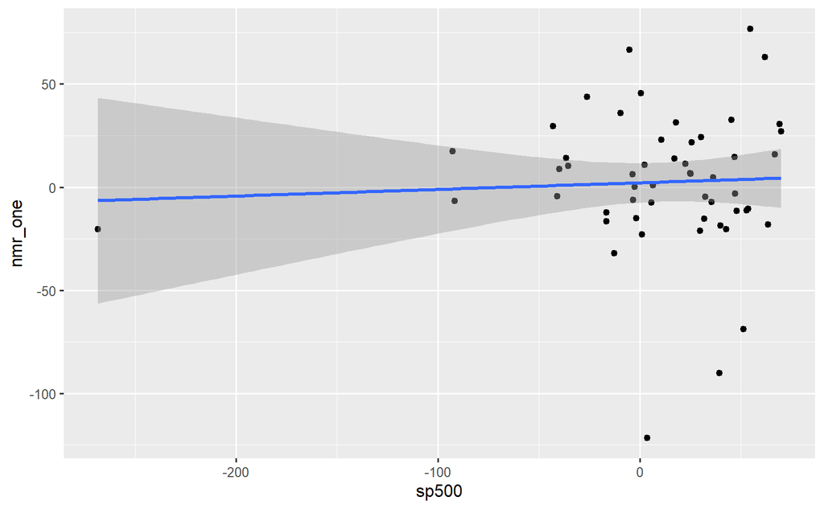

```r
ggplot(XSreal,aes(x=sp500,y=nmr_one))+
  geom_point()+
  geom_smooth(method="lm")
```

### Numerai Supreme

As of January 2024, there are still just a few observations for the Numerai Supreme fund. We’ll build out this discussion as we get more data. But for now, the beta estimates and $R^2$ values are similarly small and insignificant. However, the alpha is quite negative suggesting that the fund has struggled to deliver positive returns from its market-neutral strategy.

```r
NMR_sup_fit_nom = lm(nmr_sup~sp500,data=XSnom)
summary(NMR_sup_fit_nom)
```

```
Call:
lm(formula = nmr_sup ~ sp500, data = XSnom)

Residuals:
     Min       1Q   Median       3Q      Max
-143.002  -19.528    2.238   23.529  102.166

Coefficients:
             Estimate Std. Error t value Pr(>|t|)
(Intercept) -7.682466  13.908304  -0.552    0.588
sp500       -0.001668   0.309314  -0.005    0.996

Residual standard error: 57.58 on 16 degrees of freedom
  (35 observations deleted due to missingness)
Multiple R-squared:  1.817e-06, Adjusted R-squared:  -0.0625
F-statistic: 2.908e-05 on 1 and 16 DF,  p-value: 0.9958
```

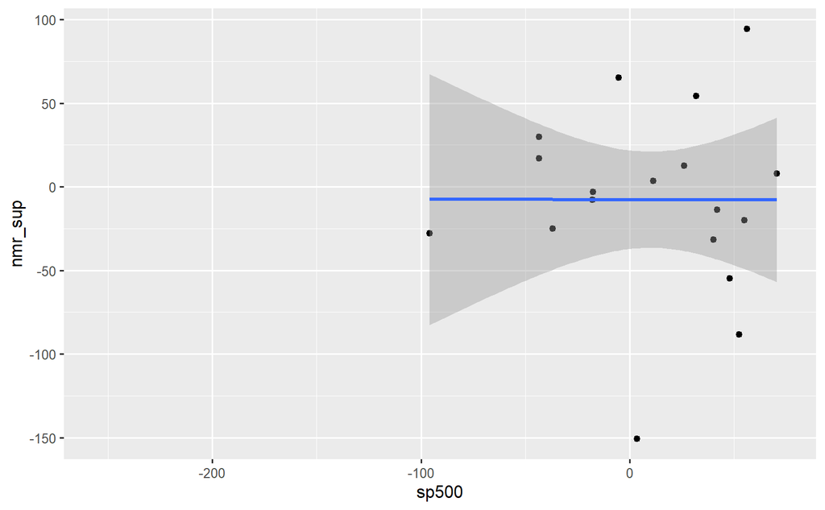

```r
ggplot(XSnom,aes(x=sp500,y=nmr_sup))+
  geom_point()+
  geom_smooth(method="lm")
```

```r
NMR_sup_fit_real = lm(nmr_sup~sp500,data=XSreal)
summary(NMR_sup_fit_real)
```

```
Call:
lm(formula = nmr_sup ~ sp500, data = XSreal)

Residuals:
     Min       1Q   Median       3Q      Max
-141.159  -19.136    2.294   22.404   99.449

Coefficients:
            Estimate Std. Error t value Pr(>|t|)
(Intercept) -7.54441   13.63527  -0.553    0.588
sp500       -0.00742    0.31275  -0.024    0.981

Residual standard error: 56.4 on 16 degrees of freedom
  (35 observations deleted due to missingness)
Multiple R-squared:  3.517e-05, Adjusted R-squared:  -0.06246
F-statistic: 0.0005628 on 1 and 16 DF,  p-value: 0.9814
```

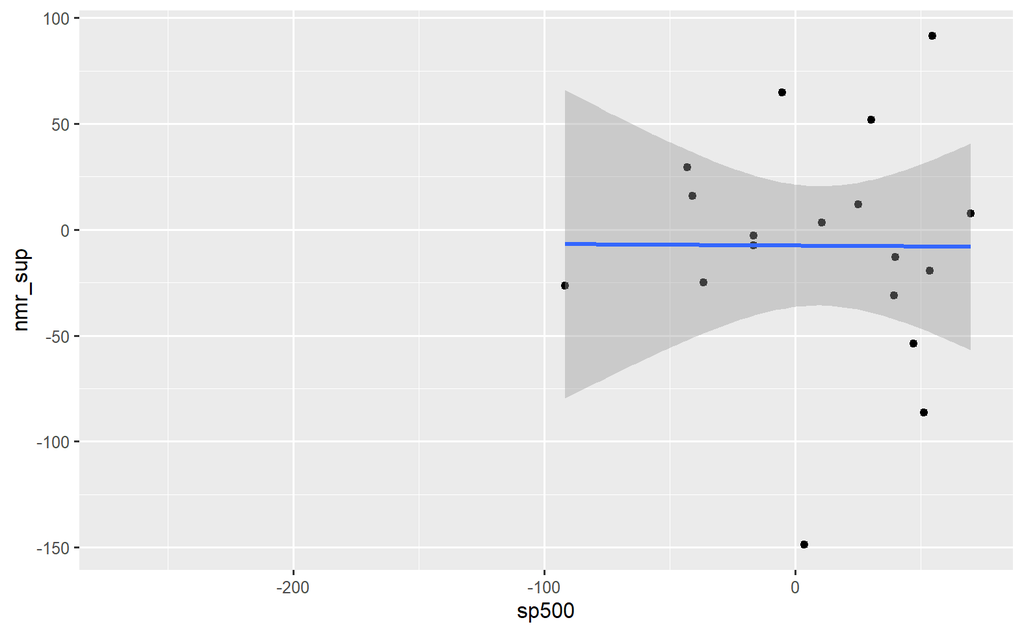

```r
ggplot(XSreal,aes(x=sp500,y=nmr_sup))+
  geom_point()+
  geom_smooth(method="lm")
```

### Numeraire (NMR) token

For the NMR token, we get some interesting results with the negative beta estimates, and the alpha estimates are quite large as well. However, the $R^2$ values are very small. So the bigger take away is that there isn’t much of a relationship here.

```r
NMR_fit_nom = lm(NMR~sp500,data=XSnom)
summary(NMR_fit_nom)
```

```
Call:
lm(formula = NMR ~ sp500, data = XSnom)

Residuals:
    Min      1Q  Median      3Q     Max
-799.68 -228.14  -26.36  202.84 1181.08

Coefficients:
            Estimate Std. Error t value Pr(>|t|)
(Intercept)  32.9227    49.8541   0.660    0.512
sp500        -0.2457     0.9207  -0.267    0.791

Residual standard error: 357.7 on 51 degrees of freedom
Multiple R-squared:  0.001395,  Adjusted R-squared:  -0.01819
F-statistic: 0.07124 on 1 and 51 DF,  p-value: 0.7906
```

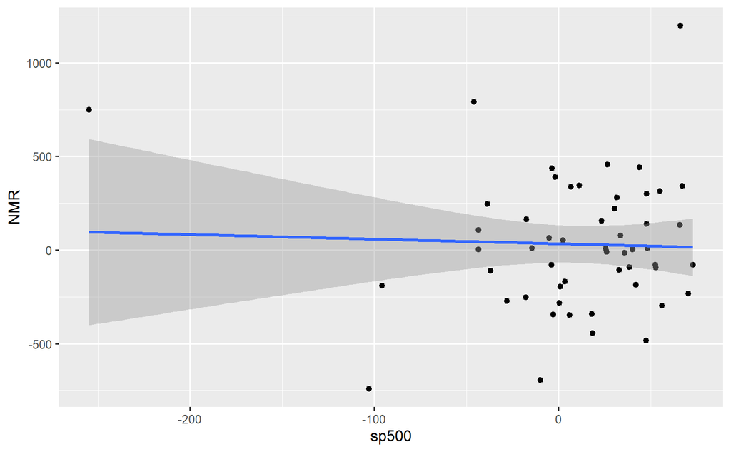

```r
ggplot(XSnom,aes(x=sp500,y=NMR))+
  geom_point()+
  geom_smooth(method="lm")
```

```r
NMR_fit_real = lm(NMR~sp500,data=XSreal)
summary(NMR_fit_real)
```

```
Call:
lm(formula = NMR ~ sp500, data = XSreal)

Residuals:
    Min      1Q  Median      3Q     Max
-747.19 -230.52  -32.19  194.27 1140.28

Coefficients:
            Estimate Std. Error t value Pr(>|t|)
(Intercept)  35.3681    47.4765   0.745    0.460
sp500        -0.4546     0.8780  -0.518    0.607

Residual standard error: 341.1 on 51 degrees of freedom
Multiple R-squared:  0.005229,  Adjusted R-squared:  -0.01428
F-statistic: 0.2681 on 1 and 51 DF,  p-value: 0.6069
```

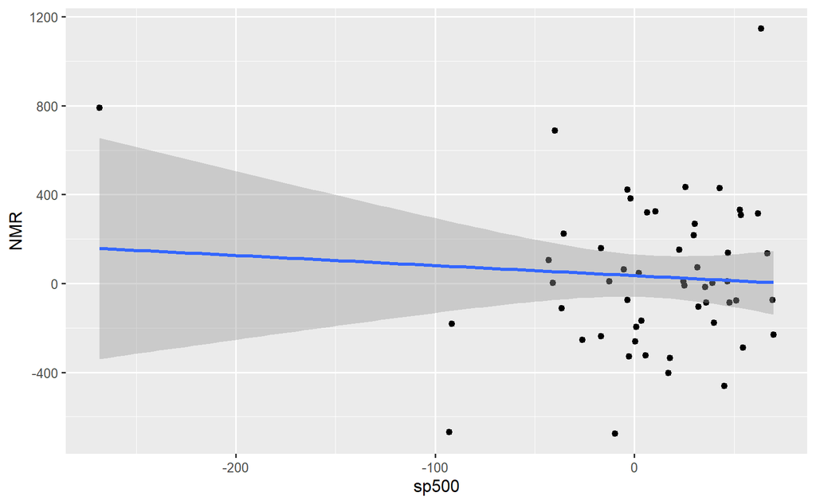

```r
ggplot(XSreal,aes(x=sp500,y=NMR))+
  geom_point()+
  geom_smooth(method="lm")
```

### Ether (ETH)

```r
ETH_fit_nom = lm(ETH~sp500,data=XSnom)
summary(ETH_fit_nom)
```

```
Call:
lm(formula = ETH ~ sp500, data = XSnom)

Residuals:
    Min      1Q  Median      3Q     Max
-637.01 -181.11  -13.69  209.23  581.68

Coefficients:
            Estimate Std. Error t value Pr(>|t|)
(Intercept)  32.7746    36.0741   0.909 0.367868
sp500         2.5585     0.6662   3.840 0.000341 ***
---
Signif. codes:  0 ‘***’ 0.001 ‘**’ 0.01 ‘*’ 0.05 ‘.’ 0.1 ‘ ’ 1

Residual standard error: 258.8 on 51 degrees of freedom
Multiple R-squared:  0.2243,    Adjusted R-squared:  0.2091
F-statistic: 14.75 on 1 and 51 DF,  p-value: 0.000341
```

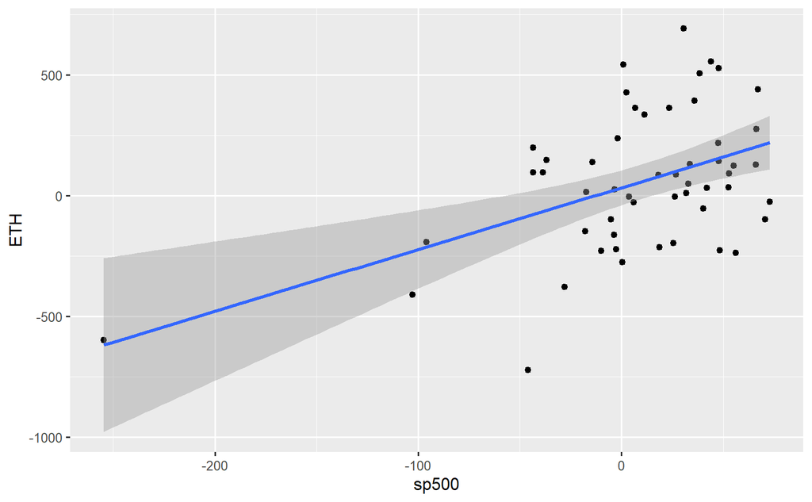

```r
ggplot(XSnom,aes(x=sp500,y=ETH))+
  geom_point()+
  geom_smooth(method="lm")
```

```r
ETH_fit_real = lm(ETH~sp500,data=XSreal)
summary(ETH_fit_real)
```

```
Call:
lm(formula = ETH ~ sp500, data = XSreal)

Residuals:
    Min      1Q  Median      3Q     Max
-561.67 -171.80  -14.92  204.11  567.40

Coefficients:
            Estimate Std. Error t value Pr(>|t|)
(Intercept)  34.1425    34.4706   0.990  0.32661
sp500         2.5187     0.6375   3.951  0.00024 ***
---
Signif. codes:  0 ‘***’ 0.001 ‘**’ 0.01 ‘*’ 0.05 ‘.’ 0.1 ‘ ’ 1

Residual standard error: 247.6 on 51 degrees of freedom
Multiple R-squared:  0.2343,    Adjusted R-squared:  0.2193
F-statistic: 15.61 on 1 and 51 DF,  p-value: 0.0002401
```

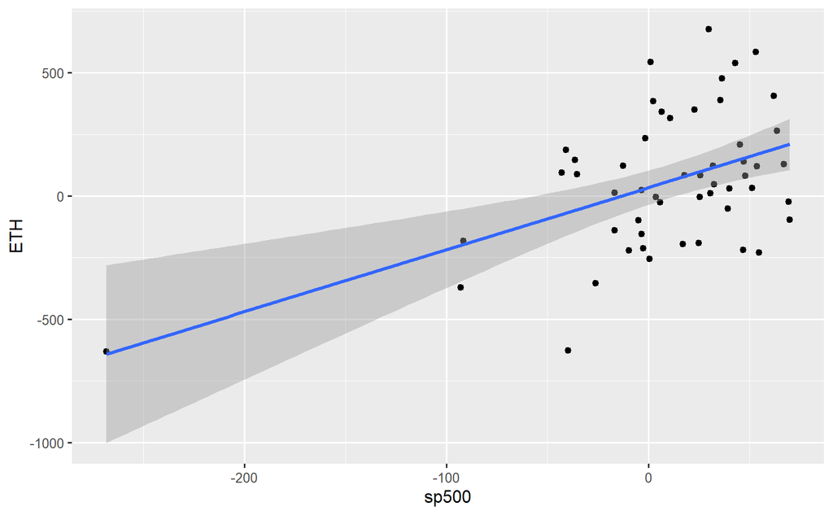

```r
ggplot(XSreal,aes(x=sp500,y=ETH))+
  geom_point()+
  geom_smooth(method="lm")
```

## Multi-Factor Models

Let’s try to incorporate some additional factors into the model to see if we can improve the explanatory power.

### ETH-Factor Models

First, let’s try to incorporate the ETH risk premium as an additional factor beyond the market risk premium.

```r
nmr_one_fit2_nom = lm(nmr_one~sp500+ETH,data=XSnom)
summary(nmr_one_fit2_nom)
```

```
Call:
lm(formula = nmr_one ~ sp500 + ETH, data = XSnom)

Residuals:
     Min       1Q   Median       3Q      Max
-127.010  -12.729   -0.758   19.031   70.235

Coefficients:
            Estimate Std. Error t value Pr(>|t|)
(Intercept)  3.30050    4.91244   0.672    0.505
sp500        0.09866    0.10219   0.965    0.339
ETH         -0.02687    0.01892  -1.420    0.162

Residual standard error: 34.97 on 50 degrees of freedom
Multiple R-squared:  0.04083,   Adjusted R-squared:  0.00246
F-statistic: 1.064 on 2 and 50 DF,  p-value: 0.3527
```

```r
nmr_one_fit2_real = lm(nmr_one~sp500+ETH,data=XSreal)
summary(nmr_one_fit2_real)
```

```
Call:
lm(formula = nmr_one ~ sp500 + ETH, data = XSreal)

Residuals:
     Min       1Q   Median       3Q      Max
-125.158  -11.838   -0.715   18.237   64.947

Coefficients:
            Estimate Std. Error t value Pr(>|t|)
(Intercept)  3.04412    4.75713    0.64    0.525
sp500        0.10157    0.09959    1.02    0.313
ETH         -0.02756    0.01914   -1.44    0.156

Residual standard error: 33.85 on 50 degrees of freedom
Multiple R-squared:  0.04232,   Adjusted R-squared:  0.00401
F-statistic: 1.105 on 2 and 50 DF,  p-value: 0.3393
```

```r
nmr_sup_fit2_nom = lm(nmr_sup~sp500+ETH,data=XSnom)
summary(nmr_sup_fit2_nom)
```

```
Call:
lm(formula = nmr_sup ~ sp500 + ETH, data = XSnom)

Residuals:
     Min       1Q   Median       3Q      Max
-144.743  -25.328    0.431   38.145   82.430

Coefficients:
             Estimate Std. Error t value Pr(>|t|)
(Intercept) -6.350227  14.163927  -0.448    0.660
sp500       -0.005051   0.312853  -0.016    0.987
ETH         -0.078656   0.098095  -0.802    0.435

Residual standard error: 58.23 on 15 degrees of freedom
  (35 observations deleted due to missingness)
Multiple R-squared:  0.0411,    Adjusted R-squared:  -0.08675
F-statistic: 0.3215 on 2 and 15 DF,  p-value: 0.7299
```

```r
nmr_sup_fit2_real = lm(nmr_sup~sp500+ETH,data=XSreal)
summary(nmr_sup_fit2_real)
```

```
Call:
lm(formula = nmr_sup ~ sp500 + ETH, data = XSreal)

Residuals:
    Min      1Q  Median      3Q     Max
-142.94  -24.72    0.91   36.97   79.26

Coefficients:
            Estimate Std. Error t value Pr(>|t|)
(Intercept) -6.18100   13.86296  -0.446    0.662
sp500       -0.01320    0.31584  -0.042    0.967
ETH         -0.08352    0.10006  -0.835    0.417

Residual standard error: 56.95 on 15 degrees of freedom
  (35 observations deleted due to missingness)
Multiple R-squared:  0.04442,   Adjusted R-squared:  -0.08299
F-statistic: 0.3486 on 2 and 15 DF,  p-value: 0.7112
```

```r
NMR_fit2_nom = lm(NMR~sp500+ETH,data=XSnom)
summary(NMR_fit2_nom)
```

```
Call:
lm(formula = NMR ~ sp500 + ETH, data = XSnom)

Residuals:
    Min      1Q  Median      3Q     Max
-732.05 -184.81  -21.47  141.94 1153.69

Coefficients:
            Estimate Std. Error t value Pr(>|t|)
(Intercept)  20.6835    48.8678   0.423   0.6739
sp500        -1.2012     1.0165  -1.182   0.2429
ETH           0.3734     0.1882   1.985   0.0527 .
---
Signif. codes:  0 ‘***’ 0.001 ‘**’ 0.01 ‘*’ 0.05 ‘.’ 0.1 ‘ ’ 1

Residual standard error: 347.8 on 50 degrees of freedom
Multiple R-squared:  0.07431,   Adjusted R-squared:  0.03728
F-statistic: 2.007 on 2 and 50 DF,  p-value: 0.1451
```

```r
NMR_fit2_real = lm(NMR~sp500+ETH,data=XSreal)
summary(NMR_fit2_real)
```

```
Call:
lm(formula = NMR ~ sp500 + ETH, data = XSreal)

Residuals:
    Min      1Q  Median      3Q     Max
-678.70 -180.57  -31.93  153.64 1112.37

Coefficients:
            Estimate Std. Error t value Pr(>|t|)
(Intercept)  21.7568    46.3357   0.470   0.6407
sp500        -1.4587     0.9701  -1.504   0.1389
ETH           0.3987     0.1864   2.138   0.0374 *
---
Signif. codes:  0 ‘***’ 0.001 ‘**’ 0.01 ‘*’ 0.05 ‘.’ 0.1 ‘ ’ 1

Residual standard error: 329.7 on 50 degrees of freedom
Multiple R-squared:  0.08857,   Adjusted R-squared:  0.05211
F-statistic: 2.429 on 2 and 50 DF,  p-value: 0.09841
```

### NMR-Factor Models

Then another factor we can try to incorporate into the model is the various Numerai assets. In other words, let’s see if the NMR token returns help explain the fund returns.

```r
num_one_fit3_nom = lm(nmr_one~sp500+ETH+NMR,data=XSnom)
summary(num_one_fit3_nom)
```

```
Call:
lm(formula = nmr_one ~ sp500 + ETH + NMR, data = XSnom)

Residuals:
     Min       1Q   Median       3Q      Max
-128.837  -11.210    0.063   18.770   72.594

Coefficients:
             Estimate Std. Error t value Pr(>|t|)
(Intercept)  3.506274   4.946788   0.709    0.482
sp500        0.086705   0.104141   0.833    0.409
ETH         -0.023155   0.019749  -1.172    0.247
NMR         -0.009949   0.014290  -0.696    0.490

Residual standard error: 35.15 on 49 degrees of freedom
Multiple R-squared:  0.05022,   Adjusted R-squared:  -0.007929
F-statistic: 0.8637 on 3 and 49 DF,  p-value: 0.4663
```

```r
num_one_fit3_real = lm(nmr_one~sp500+ETH+NMR,data=XSreal)
summary(num_one_fit3_real)
```

```
Call:
lm(formula = nmr_one ~ sp500 + ETH + NMR, data = XSreal)

Residuals:
     Min       1Q   Median       3Q      Max
-127.013  -10.744    0.158   16.924   67.214

Coefficients:
            Estimate Std. Error t value Pr(>|t|)
(Intercept)  3.26633    4.79212   0.682    0.499
sp500        0.08667    0.10234   0.847    0.401
ETH         -0.02349    0.02010  -1.169    0.248
NMR         -0.01021    0.01459  -0.700    0.487

Residual standard error: 34.03 on 49 degrees of freedom
Multiple R-squared:  0.0518,    Adjusted R-squared:  -0.006258
F-statistic: 0.8922 on 3 and 49 DF,  p-value: 0.4519
```

```r
num_sup_fit3_nom = lm(nmr_sup~sp500+ETH+NMR,data=XSnom)
summary(num_sup_fit3_nom)
```

```
Call:
lm(formula = nmr_sup ~ sp500 + ETH + NMR, data = XSnom)

Residuals:
    Min      1Q  Median      3Q     Max
-126.18  -35.88   19.16   28.17   92.02

Coefficients:
            Estimate Std. Error t value Pr(>|t|)
(Intercept) -3.03486   13.88230  -0.219    0.830
sp500       -0.05235    0.30415  -0.172    0.866
ETH         -0.20191    0.12792  -1.578    0.137
NMR          0.13211    0.09205   1.435    0.173

Residual standard error: 56.28 on 14 degrees of freedom
  (35 observations deleted due to missingness)
Multiple R-squared:  0.1641,    Adjusted R-squared:  -0.01505
F-statistic: 0.916 on 3 and 14 DF,  p-value: 0.4584
```

```r
num_sup_fit3_real = lm(nmr_sup~sp500+ETH+NMR,data=XSreal)
summary(num_sup_fit3_real)
```

```
Call:
lm(formula = nmr_sup ~ sp500 + ETH + NMR, data = XSreal)

Residuals:
    Min      1Q  Median      3Q     Max
-124.07  -35.07   19.41   28.03   88.79

Coefficients:
            Estimate Std. Error t value Pr(>|t|)
(Intercept) -2.89371   13.55139  -0.214    0.834
sp500       -0.05994    0.30614  -0.196    0.848
ETH         -0.20967    0.12937  -1.621    0.127
NMR          0.13559    0.09266   1.463    0.165

Residual standard error: 54.9 on 14 degrees of freedom
  (35 observations deleted due to missingness)
Multiple R-squared:  0.1712,    Adjusted R-squared:  -0.006421
F-statistic: 0.9638 on 3 and 14 DF,  p-value: 0.4371
```

### Fama/French Research Factors

A popular asset pricing model in the finance literature has been the factor models from Fama and French (1993), which introduced a three-factor model that includes SMB (Small Minus Big) as a ‘size’ factor and HML (High Minus Low) as a ‘value’/‘growth’ factor. See [the 3-Factors webpage](https://mba.tuck.dartmouth.edu/pages/faculty/ken.french/Data_Library/f-f_factors.html) for more detail. Additionally the more recent [Fama and French (2015)](https://doi.org/10.1016/j.jfineco.2014.10.010) includes two additional factors: RMW (Robust Minus Weak) as a ‘profitability’ factor and CMA (Conservative Minus Aggressive) factor. The [5-Factors webpage](https://mba.tuck.dartmouth.edu/pages/faculty/ken.french/Data_Library/f-f_5_factors_2x3.html) has more detail. The codes below import the factor data from the website and conduct those regressions on the Numerai returns.

```r
ff3url = "https://mba.tuck.dartmouth.edu/pages/faculty/ken.french/ftp/F-F_Research_Data_Factors_CSV.zip"
# Create subdirectory for file downloads
subdirectory = "Factor Data"
dir.create(subdirectory, showWarnings=FALSE)
# Define the file paths
zip_filepath = file.path(subdirectory, "FF3-factors.zip")
csv_filepath = file.path(subdirectory, "FF3-factors.csv")
# Download the zip file
download.file(ff3url, destfile=zip_filepath)
# Extract the CSV file from the zip file
unzip(zip_filepath, exdir=subdirectory)
file.rename("Factor Data/F-F_Research_Data_Factors.CSV", csv_filepath)
```

```
[1] TRUE
```

```r
FF3 = read_csv(csv_filepath,
               col_types = cols(...1 = col_date(format = "%Y%m")),
               skip = 2)
```

[output not shown]

```r
FF3 = FF3 |> rename(Date=...1)
# Trim annual observations from bottom of date frame (dates import as missing)
FF3 = FF3[complete.cases(FF3),]
# Reformat to xts object
FF3xts = xts(FF3[,-1], order.by=FF3$Date)
# Remove data prior to first BTC observation
FF3xts = FF3xts[paste(startdate,"/",sep="")]
```

```r
# Compile data frame of annualized crypto returns (un-annualize)
assets_ff3 = merge(XSreal,
                   FF3xts*12)
#assets_ff3 = assets_ff3[complete.cases(assets_ff3),]
# Compute average annual returns, volatility, and correlations
Er_ff3 = colMeans(assets_ff3,na.rm=TRUE)
Er_ff3 |> round(2)
```

```
  sp500 nmr_one nmr_sup     NMR     ETH  Mkt.RF     SMB     HML      RF
   8.75    2.38   -7.62   31.39   56.18   12.75    0.81    0.90    1.68
```

```r
sd_ff3 = apply(assets_ff3,2,sd,na.rm=TRUE)
sd_ff3 |> round(2)
```

```
  sp500 nmr_one nmr_sup     NMR     ETH  Mkt.RF     SMB     HML      RF
  53.87   33.92   54.72  338.67  280.28   68.82   36.59   58.88    2.01
```

```r
Sharpe_ff3 = Er_ff3/sd_ff3
Sharpe_ff3 |> round(2)
```

```
  sp500 nmr_one nmr_sup     NMR     ETH  Mkt.RF     SMB     HML      RF
   0.16    0.07   -0.14    0.09    0.20    0.19    0.02    0.02    0.84
```

```r
cor(assets_ff3, use="pairwise.complete.obs") |> round(2)
```

```
        sp500 nmr_one nmr_sup   NMR   ETH Mkt.RF   SMB   HML    RF
sp500    1.00    0.05   -0.01 -0.07  0.48   0.58  0.37  0.17 -0.04
nmr_one  0.05    1.00    0.88 -0.15 -0.15  -0.10 -0.18  0.19 -0.26
nmr_sup -0.01    0.88    1.00  0.12 -0.21  -0.22 -0.26  0.37 -0.23
NMR     -0.07   -0.15    0.12  1.00  0.22   0.08  0.12 -0.25  0.02
ETH      0.48   -0.15   -0.21  0.22  1.00   0.64  0.31  0.00 -0.12
Mkt.RF   0.58   -0.10   -0.22  0.08  0.64   1.00  0.32  0.04 -0.05
SMB      0.37   -0.18   -0.26  0.12  0.31   0.32  1.00  0.05 -0.09
HML      0.17    0.19    0.37 -0.25  0.00   0.04  0.05  1.00 -0.11
RF      -0.04   -0.26   -0.23  0.02 -0.12  -0.05 -0.09 -0.11  1.00
```

```r
# FF3 regressions
FF3reg_nmr_one = lm(nmr_one~Mkt.RF+SMB+HML, data=assets_ff3)
summary(FF3reg_nmr_one)
```

```
Call:
lm(formula = nmr_one ~ Mkt.RF + SMB + HML, data = assets_ff3)

Residuals:
     Min       1Q   Median       3Q      Max
-110.364  -15.877   -2.962   20.979   66.729

Coefficients:
            Estimate Std. Error t value Pr(>|t|)
(Intercept)  2.82856    4.89303   0.578    0.566
Mkt.RF      -0.02812    0.07441  -0.378    0.707
SMB         -0.16055    0.14001  -1.147    0.257
HML          0.11714    0.08256   1.419    0.163

Residual standard error: 34.32 on 47 degrees of freedom
  (2 observations deleted due to missingness)
Multiple R-squared:  0.07364,   Adjusted R-squared:  0.01451
F-statistic: 1.245 on 3 and 47 DF,  p-value: 0.3039
```

```r
FF3reg_nmr_sup = lm(nmr_sup~Mkt.RF+SMB+HML, data=assets_ff3)
summary(FF3reg_nmr_sup)
```

```
Call:
lm(formula = nmr_sup ~ Mkt.RF + SMB + HML, data = assets_ff3)

Residuals:
   Min     1Q Median     3Q    Max
-80.04 -31.06 -11.64  16.12  80.94

Coefficients:
            Estimate Std. Error t value Pr(>|t|)
(Intercept)  -8.9580    12.8814  -0.695   0.4990
Mkt.RF       -0.1607     0.2122  -0.757   0.4625
SMB          -0.4598     0.3661  -1.256   0.2313
HML           0.5416     0.2724   1.988   0.0683 .
---
Signif. codes:  0 ‘***’ 0.001 ‘**’ 0.01 ‘*’ 0.05 ‘.’ 0.1 ‘ ’ 1

Residual standard error: 52.1 on 13 degrees of freedom
  (36 observations deleted due to missingness)
Multiple R-squared:  0.3013,    Adjusted R-squared:   0.14
F-statistic: 1.868 on 3 and 13 DF,  p-value: 0.1848
```

```r
FF3reg_NMR = lm(NMR~Mkt.RF+SMB+HML, data=assets_ff3)
summary(FF3reg_NMR)
```

```
Call:
lm(formula = NMR ~ Mkt.RF + SMB + HML, data = assets_ff3)

Residuals:
    Min      1Q  Median      3Q     Max
-744.30 -209.81   -9.11  200.10 1038.20

Coefficients:
            Estimate Std. Error t value Pr(>|t|)
(Intercept)  31.6724    48.5483   0.652   0.5173
Mkt.RF        0.2874     0.7383   0.389   0.6988
SMB           1.1061     1.3891   0.796   0.4299
HML          -1.5016     0.8192  -1.833   0.0731 .
---
Signif. codes:  0 ‘***’ 0.001 ‘**’ 0.01 ‘*’ 0.05 ‘.’ 0.1 ‘ ’ 1

Residual standard error: 340.5 on 47 degrees of freedom
  (2 observations deleted due to missingness)
Multiple R-squared:  0.08299,   Adjusted R-squared:  0.02446
F-statistic: 1.418 on 3 and 47 DF,  p-value: 0.2494
```

```r
FF3reg_ETH = lm(ETH~Mkt.RF+SMB+HML, data=assets_ff3)
summary(FF3reg_ETH)
```

```
Call:
lm(formula = ETH ~ Mkt.RF + SMB + HML, data = assets_ff3)

Residuals:
    Min      1Q  Median      3Q     Max
-434.25 -129.38    7.98  115.38  572.82

Coefficients:
            Estimate Std. Error t value Pr(>|t|)
(Intercept)  25.0110    31.9051   0.784    0.437
Mkt.RF        2.4985     0.4852   5.150 5.06e-06 ***
SMB           0.9568     0.9129   1.048    0.300
HML          -0.1360     0.5383  -0.253    0.802
---
Signif. codes:  0 ‘***’ 0.001 ‘**’ 0.01 ‘*’ 0.05 ‘.’ 0.1 ‘ ’ 1

Residual standard error: 223.8 on 47 degrees of freedom
  (2 observations deleted due to missingness)
Multiple R-squared:  0.4233,    Adjusted R-squared:  0.3864
F-statistic:  11.5 on 3 and 47 DF,  p-value: 8.972e-06
```

```r
ff5url = "https://mba.tuck.dartmouth.edu/pages/faculty/ken.french/ftp/F-F_Research_Data_5_Factors_2x3_CSV.zip"
# Define the file paths
zip_filepath = file.path(subdirectory, "FF5-factors.zip")
csv_filepath = file.path(subdirectory, "FF5-factors.csv")
# Download the zip file
download.file(ff5url, destfile=zip_filepath)
# Extract the CSV file from the zip file
unzip(zip_filepath, exdir=subdirectory)
file.rename("Factor Data/F-F_Research_Data_5_Factors_2x3.CSV", csv_filepath)
```

```
[1] TRUE
```

```r
FF5 = read_csv(csv_filepath,
               col_types = cols(...1 = col_date(format = "%Y%m")),
               skip = 2)
```

[output not shown]

```r
FF5 = FF5 |> rename(Date=...1)
# Trim annual observations from bottom of date frame (dates import as missing)
FF5 = FF5[complete.cases(FF5),]
# For some reason, the factors are importing as characters, so this will fix those
FF5$`Mkt-RF` = as.numeric(FF5$`Mkt-RF`)*12
FF5$SMB = as.numeric(FF5$SMB)*12
FF5$HML = as.numeric(FF5$HML)*12
FF5$RMW = as.numeric(FF5$RMW)*12
FF5$CMA = as.numeric(FF5$CMA)*12
# Reformat to xts object
FF5xts = xts(FF5[,-1], order.by=FF5$Date)
# Remove data prior to first BTC observation
FF5xts = FF5xts[paste(startdate,"/",sep="")]
```

```r
# Compile data frame of annualized crypto returns (un-annualize)
assets_ff5 = merge(XSreal, FF5xts)
#assets_ff5 = assets_ff5[complete.cases(assets_ff5),]
# Compute average annual returns, volatility, and correlations
Er_ff5 = colMeans(assets_ff5,na.rm=TRUE)
Er_ff5 |> round(2)
```

```
  sp500 nmr_one nmr_sup     NMR     ETH  Mkt.RF     SMB     HML     RMW     CMA      RF
   8.75    2.38   -7.62   31.39   56.18   12.75    0.66    0.90    7.51    2.40    0.14
```

```r
sd_ff5 = apply(assets_ff5,2,sd,na.rm=TRUE)
sd_ff5 |> round(2)
```

```
  sp500 nmr_one nmr_sup     NMR     ETH  Mkt.RF     SMB     HML     RMW     CMA      RF
  53.87   33.92   54.72  338.67  280.28   68.82   39.61   58.88   33.33   37.86    0.17
```

```r
Sharpe_ff5 = Er_ff5/sd_ff5
Sharpe_ff5 |> round(2)
```

```
  sp500 nmr_one nmr_sup     NMR     ETH  Mkt.RF     SMB     HML     RMW     CMA      RF
   0.16    0.07   -0.14    0.09    0.20    0.19    0.02    0.02    0.23    0.06    0.84
```

```r
cor(assets_ff5, use="pairwise.complete.obs") |> round(2)
```

```
        sp500 nmr_one nmr_sup   NMR   ETH Mkt.RF   SMB   HML   RMW   CMA    RF
sp500    1.00    0.05   -0.01 -0.07  0.48   0.58  0.42  0.17  0.05 -0.13 -0.04
nmr_one  0.05    1.00    0.88 -0.15 -0.15  -0.10 -0.08  0.19  0.13  0.26 -0.26
nmr_sup -0.01    0.88    1.00  0.12 -0.21  -0.22 -0.11  0.37  0.40  0.62 -0.23
NMR     -0.07   -0.15    0.12  1.00  0.22   0.08  0.05 -0.25  0.00 -0.21  0.02
ETH      0.48   -0.15   -0.21  0.22  1.00   0.64  0.29  0.00 -0.05 -0.19 -0.12
Mkt.RF   0.58   -0.10   -0.22  0.08  0.64   1.00  0.34  0.04  0.08 -0.18 -0.05
SMB      0.42   -0.08   -0.11  0.05  0.29   0.34  1.00  0.35 -0.41  0.01 -0.10
HML      0.17    0.19    0.37 -0.25  0.00   0.04  0.35  1.00  0.17  0.67 -0.11
RMW      0.05    0.13    0.40  0.00 -0.05   0.08 -0.41  0.17  1.00  0.17 -0.08
CMA     -0.13    0.26    0.62 -0.21 -0.19  -0.18  0.01  0.67  0.17  1.00 -0.19
RF      -0.04   -0.26   -0.23  0.02 -0.12  -0.05 -0.10 -0.11 -0.08 -0.19  1.00
```

```r
# FF3 regressions
FF5reg_nmr_one = lm(nmr_one~Mkt.RF+SMB+HML+RMW+CMA, data=assets_ff5)
summary(FF5reg_nmr_one)
```

```
Call:
lm(formula = nmr_one ~ Mkt.RF + SMB + HML + RMW + CMA, data = assets_ff5)

Residuals:
     Min       1Q   Median       3Q      Max
-103.223  -18.878    0.737   23.282   64.774

Coefficients:
            Estimate Std. Error t value Pr(>|t|)
(Intercept)  1.91331    5.13823   0.372    0.711
Mkt.RF      -0.02713    0.08180  -0.332    0.742
SMB         -0.05846    0.17876  -0.327    0.745
HML          0.04737    0.13454   0.352    0.726
RMW          0.06209    0.18454   0.336    0.738
CMA          0.16982    0.18808   0.903    0.371

Residual standard error: 34.91 on 45 degrees of freedom
  (2 observations deleted due to missingness)
Multiple R-squared:  0.0821,    Adjusted R-squared:  -0.01989
F-statistic: 0.805 on 5 and 45 DF,  p-value: 0.5522
```

```r
FF5reg_nmr_sup = lm(nmr_sup~Mkt.RF+SMB+HML+RMW+CMA, data=assets_ff5)
summary(FF5reg_nmr_sup)
```

```
Call:
lm(formula = nmr_sup ~ Mkt.RF + SMB + HML + RMW + CMA, data = assets_ff5)

Residuals:
    Min      1Q  Median      3Q     Max
-68.814 -25.306  -1.263  23.001  67.982

Coefficients:
            Estimate Std. Error t value Pr(>|t|)
(Intercept)  -6.4193    11.8098  -0.544    0.598
Mkt.RF       -0.2559     0.2034  -1.258    0.235
SMB           0.3242     0.5122   0.633    0.540
HML          -0.3028     0.4933  -0.614    0.552
RMW           0.5276     0.4714   1.119    0.287
CMA           1.0103     0.5397   1.872    0.088 .
---
Signif. codes:  0 ‘***’ 0.001 ‘**’ 0.01 ‘*’ 0.05 ‘.’ 0.1 ‘ ’ 1

Residual standard error: 47.06 on 11 degrees of freedom
  (36 observations deleted due to missingness)
Multiple R-squared:  0.5175,    Adjusted R-squared:  0.2982
F-statistic:  2.36 on 5 and 11 DF,  p-value: 0.1094
```

```r
FF5reg_NMR = lm(NMR~Mkt.RF+SMB+HML+RMW+CMA, data=assets_ff5)
summary(FF5reg_NMR)
```

```
Call:
lm(formula = NMR ~ Mkt.RF + SMB + HML + RMW + CMA, data = assets_ff5)

Residuals:
    Min      1Q  Median      3Q     Max
-738.65 -224.76   22.99  186.23  982.53

Coefficients:
            Estimate Std. Error t value Pr(>|t|)
(Intercept) 22.24370   50.64941   0.439    0.663
Mkt.RF       0.01200    0.80629   0.015    0.988
SMB          2.14569    1.76208   1.218    0.230
HML         -2.14107    1.32619  -1.614    0.113
RMW          1.71646    1.81906   0.944    0.350
CMA          0.04456    1.85400   0.024    0.981

Residual standard error: 344.2 on 45 degrees of freedom
  (2 observations deleted due to missingness)
Multiple R-squared:  0.1032,    Adjusted R-squared:  0.0035
F-statistic: 1.035 on 5 and 45 DF,  p-value: 0.4087
```

```r
FF5reg_ETH = lm(ETH~Mkt.RF+SMB+HML+RMW+CMA, data=assets_ff5)
summary(FF5reg_ETH)
```

```
Call:
lm(formula = ETH ~ Mkt.RF + SMB + HML + RMW + CMA, data = assets_ff5)

Residuals:
    Min      1Q  Median      3Q     Max
-419.79 -132.03   18.03  132.66  633.60

Coefficients:
            Estimate Std. Error t value Pr(>|t|)
(Intercept)  31.2476    33.5716   0.931    0.357
Mkt.RF        2.5461     0.5344   4.764 2.01e-05 ***
SMB           0.2602     1.1679   0.223    0.825
HML           0.2174     0.8790   0.247    0.806
RMW          -0.6285     1.2057  -0.521    0.605
CMA          -0.7664     1.2289  -0.624    0.536
---
Signif. codes:  0 ‘***’ 0.001 ‘**’ 0.01 ‘*’ 0.05 ‘.’ 0.1 ‘ ’ 1

Residual standard error: 228.1 on 45 degrees of freedom
  (2 observations deleted due to missingness)
Multiple R-squared:  0.4262,    Adjusted R-squared:  0.3625
F-statistic: 6.685 on 5 and 45 DF,  p-value: 9.839e-05
```